# Breast Cancer Prediction

## 0. Background

Breast cancer is the most common cancer among women and the second leading cause of cancer death. Early diagnosis of cancer is critical. The sample obtained by an invasive technique can be easily digitized and used for computationally based diagnostic. Using machine learning methods for diagnostic can significantly increase processing speed and on a big scale can make the diagnostic significantly cheaper.

In this data challenge, we analyze the “Breast Cancer Wisconsin (Original)” dataset from UCI Machine Learning Repository. Features in this dataset were computed from a digitized image of a fine needle aspirate (FNA) of a breast mass. They describe characteristics of the cell nuclei present in the image. Several nuclei in each sample were analyzed. The dataset contains 699 observations and 9 attributes, and some missing values.

## 1. Data Loading and Cleaning

```python
import pandas as pd
import matplotlib.pyplot as plt
import seaborn as sns
import numpy as np
import itertools
import timeit

%matplotlib inline
```

### Load data

```python
# create column name list based on the project description
col_names = ['clump_thickness', 'uniformity_cell_size', 'uniformity_cell_shape',
             'marginal_adhesion', 'single_epithelial_cell_size', 'bare_nuclei', 'bland_chromatin',
             'normal_nucleoli', 'mitoses', 'diagnosis']

# load data
cancer_df = pd.read_csv('breast-cancer-wisconsin.data', header=None, index_col=0, names=col_names)
cancer_df.head()
```

|  | clump_thickness | uniformity_cell_size | uniformity_cell_shape | marginal_adhesion | single_epithelial_cell_size | bare_nuclei | bland_chromatin | normal_nucleoli | mitoses | diagnosis |
| --- | --- | --- | --- | --- | --- | --- | --- | --- | --- | --- |
| 1000025 | 5 | 1 | 1 | 1 | 2 | 1 | 3 | 1 | 1 | 2 |
| 1002945 | 5 | 4 | 4 | 5 | 7 | 10 | 3 | 2 | 1 | 2 |
| 1015425 | 3 | 1 | 1 | 1 | 2 | 2 | 3 | 1 | 1 | 2 |
| 1016277 | 6 | 8 | 8 | 1 | 3 | 4 | 3 | 7 | 1 | 2 |
| 1017023 | 4 | 1 | 1 | 3 | 2 | 1 | 3 | 1 | 1 | 2 |

```python
# drop sample_code column since id is not needed in furthur analysis
#cancer_df.drop("sample_code", axis=1, inplace=True)
```

### Check if there are missing values

```python
cancer_df.info()
```

```
<class 'pandas.core.frame.DataFrame'>
Int64Index: 699 entries, 1000025 to 897471
Data columns (total 10 columns):
clump_thickness                699 non-null int64
uniformity_cell_size           699 non-null int64
uniformity_cell_shape          699 non-null int64
marginal_adhesion              699 non-null int64
single_epithelial_cell_size    699 non-null int64
bare_nuclei                    699 non-null object
bland_chromatin                699 non-null int64
normal_nucleoli                699 non-null int64
mitoses                        699 non-null int64
diagnosis                      699 non-null int64
dtypes: int64(9), object(1)
memory usage: 60.1+ KB
```

```python
cancer_df.groupby('diagnosis').describe().T
```

|  | diagnosis | 2 | 4 |
| --- | --- | --- | --- |
| bland_chromatin | count | 458.000000 | 241.000000 |
|  | mean | 2.100437 | 5.979253 |
|  | std | 1.080339 | 2.273852 |
|  | min | 1.000000 | 1.000000 |
|  | 25% | 1.000000 | 4.000000 |
|  | 50% | 2.000000 | 7.000000 |
|  | 75% | 3.000000 | 7.000000 |
|  | max | 7.000000 | 10.000000 |
| clump_thickness | count | 458.000000 | 241.000000 |
|  | mean | 2.956332 | 7.195021 |
|  | std | 1.674318 | 2.428849 |
|  | min | 1.000000 | 1.000000 |
|  | 25% | 1.000000 | 5.000000 |
|  | 50% | 3.000000 | 8.000000 |
|  | 75% | 4.000000 | 10.000000 |
|  | max | 8.000000 | 10.000000 |
| marginal_adhesion | count | 458.000000 | 241.000000 |
|  | mean | 1.364629 | 5.547718 |
|  | std | 0.996830 | 3.210465 |
|  | min | 1.000000 | 1.000000 |
|  | 25% | 1.000000 | 3.000000 |
|  | 50% | 1.000000 | 5.000000 |
|  | 75% | 1.000000 | 8.000000 |
|  | max | 10.000000 | 10.000000 |
| mitoses | count | 458.000000 | 241.000000 |
|  | mean | 1.063319 | 2.589212 |
|  | std | 0.501995 | 2.557939 |
|  | min | 1.000000 | 1.000000 |
|  | 25% | 1.000000 | 1.000000 |
|  | 50% | 1.000000 | 1.000000 |
| ... | ... | ... | ... |
| normal_nucleoli | std | 1.058856 | 3.350672 |
|  | min | 1.000000 | 1.000000 |
|  | 25% | 1.000000 | 3.000000 |
|  | 50% | 1.000000 | 6.000000 |
|  | 75% | 1.000000 | 10.000000 |
|  | max | 9.000000 | 10.000000 |
| single_epithelial_cell_size | count | 458.000000 | 241.000000 |
|  | mean | 2.120087 | 5.298755 |
|  | std | 0.917130 | 2.451606 |
|  | min | 1.000000 | 1.000000 |
|  | 25% | 2.000000 | 3.000000 |
|  | 50% | 2.000000 | 5.000000 |
|  | 75% | 2.000000 | 6.000000 |
|  | max | 10.000000 | 10.000000 |
| uniformity_cell_shape | count | 458.000000 | 241.000000 |
|  | mean | 1.443231 | 6.560166 |
|  | std | 0.997836 | 2.562045 |
|  | min | 1.000000 | 1.000000 |
|  | 25% | 1.000000 | 4.000000 |
|  | 50% | 1.000000 | 6.000000 |
|  | 75% | 1.000000 | 9.000000 |
|  | max | 8.000000 | 10.000000 |
| uniformity_cell_size | count | 458.000000 | 241.000000 |
|  | mean | 1.325328 | 6.572614 |
|  | std | 0.907694 | 2.719512 |
|  | min | 1.000000 | 1.000000 |
|  | 25% | 1.000000 | 4.000000 |
|  | 50% | 1.000000 | 6.000000 |
|  | 75% | 1.000000 | 10.000000 |
|  | max | 9.000000 | 10.000000 |

64 rows × 2 columns

It seems that there is no missing values from isnull() check, but when we check dtypes of each column, we saw the type of bare_nuclie is an object rather than integer. There might be something wrong with this column. So we give it a further check.

```python
cancer_df['bare_nuclei'].value_counts()
```

```
1     402
10    132
2      30
5      30
3      28
8      21
4      19
?      16
9       9
7       8
6       4
Name: bare_nuclei, dtype: int64
```

There are 16 missing values in bare_nuclei feature. We omit them in our analysis since they are only 16/699 = 2% of our dataset. We may also want to find a way to fill these 16 missing values in the future.

```python
# drop missing values
cancer_df.drop(cancer_df[cancer_df.bare_nuclei == '?'].index, inplace=True)
#cancer_df['bare_nuclei'].replace('?', np.nan, inplace=True)
#cancer_df.dropna(subset=['bare_nuclei'], how='any', inplace=True)
cancer_df['bare_nuclei'] = pd.to_numeric(cancer_df['bare_nuclei'],errors='coerce')
#cancer_df['bare_nuclei'] = cancer_df['bare_nuclei'].apply(pd.to_numeric)
```

```python
cancer_df['bare_nuclei'].value_counts()
```

```
1     401
10    132
5      30
2      30
3      28
8      21
4      19
9       9
7       8
6       4
Name: bare_nuclei, dtype: int64
```

## 2. Data Exploration

### First let's see the statistics of our data

```python
cancer_df.describe()
```

|  | clump_thickness | uniformity_cell_size | uniformity_cell_shape | marginal_adhesion | single_epithelial_cell_size | bare_nuclei | bland_chromatin | normal_nucleoli | mitoses | diagnosis |
| --- | --- | --- | --- | --- | --- | --- | --- | --- | --- | --- |
| count | 682.000000 | 682.000000 | 682.000000 | 682.000000 | 682.000000 | 682.000000 | 682.000000 | 682.000000 | 682.000000 | 682.000000 |
| mean | 4.444282 | 3.153959 | 3.218475 | 2.832845 | 3.236070 | 3.548387 | 3.445748 | 2.872434 | 1.604106 | 2.700880 |
| std | 2.822290 | 3.066285 | 2.989568 | 2.865805 | 2.224214 | 3.645226 | 2.451435 | 3.054065 | 1.733792 | 0.954916 |
| min | 1.000000 | 1.000000 | 1.000000 | 1.000000 | 1.000000 | 1.000000 | 1.000000 | 1.000000 | 1.000000 | 2.000000 |
| 25% | 2.000000 | 1.000000 | 1.000000 | 1.000000 | 2.000000 | 1.000000 | 2.000000 | 1.000000 | 1.000000 | 2.000000 |
| 50% | 4.000000 | 1.000000 | 1.000000 | 1.000000 | 2.000000 | 1.000000 | 3.000000 | 1.000000 | 1.000000 | 2.000000 |
| 75% | 6.000000 | 5.000000 | 5.000000 | 4.000000 | 4.000000 | 6.000000 | 5.000000 | 4.000000 | 1.000000 | 4.000000 |
| max | 10.000000 | 10.000000 | 10.000000 | 10.000000 | 10.000000 | 10.000000 | 10.000000 | 10.000000 | 10.000000 | 4.000000 |

### Let's get the frequency of cancer stages

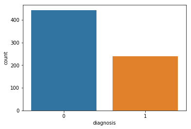

```python
cancer_df['diagnosis'] = cancer_df['diagnosis'].map({2:0, 4:1}) # 0 for benign
sns.countplot(x='diagnosis', data=cancer_df)
plt.show()
```

We can see that this dataset has around twice as much Benign stage than Malignant stage. This is typical for a cancer dataset. This data is not extremely unbalanced and we'll keep it as is in the following analysis.

### Feature Selection 1 - Nucleus features vs Diagnosis

In particular, we'd like to know how the shape changes when we restrict to malignant and benign tumors. If we were MDs, our training would likely consist of seeing what features are present in each case. So let's first visualize that.

```python
feature_names = list(cancer_df.columns[0:9])
# split dataframe into two based on diagnosis
dfM = cancer_df[cancer_df['diagnosis'] == 1]
dfB = cancer_df[cancer_df['diagnosis'] == 0]
```

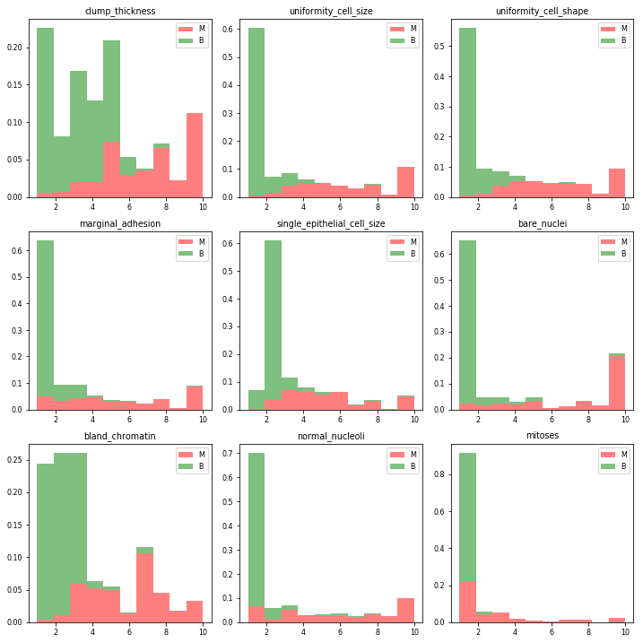

```python
#Stack the data
plt.rcParams.update({'font.size': 8})
fig, axes = plt.subplots(nrows=3, ncols=3, figsize=(10,10))
axes = axes.ravel()
for idx,ax in enumerate(axes):
    ax.figure
    binwidth= (max(cancer_df[feature_names[idx]]) - min(cancer_df[feature_names[idx]]))/10
    ax.hist([dfM[feature_names[idx]],dfB[feature_names[idx]]],
            bins=np.arange(min(cancer_df[feature_names[idx]]), max(cancer_df[feature_names[idx]]) + binwidth, binwidth),
            alpha=0.5,stacked=True, normed = True, label=['M','B'],color=['r','g'])
    ax.legend(loc='upper right')
    ax.set_title(feature_names[idx])
plt.tight_layout()
plt.show()
```

#### Observations

- Mitoses does not show a particular preference of one diagnosis over the other.
- For all other features, larger values of these parameters tends to show a correlation with malignant tumors. So these features can be used in classify cancer cells.

```python
df = cancer_df.copy()
cols = col_names

df.info()
```

```
<class 'pandas.core.frame.DataFrame'>
Int64Index: 682 entries, 1000025 to 897471
Data columns (total 10 columns):
clump_thickness                682 non-null int64
uniformity_cell_size           682 non-null int64
uniformity_cell_shape          682 non-null int64
marginal_adhesion              682 non-null int64
single_epithelial_cell_size    682 non-null int64
bare_nuclei                    682 non-null int64
bland_chromatin                682 non-null int64
normal_nucleoli                682 non-null int64
mitoses                        682 non-null int64
diagnosis                      682 non-null int64
dtypes: int64(10)
memory usage: 58.6 KB
```

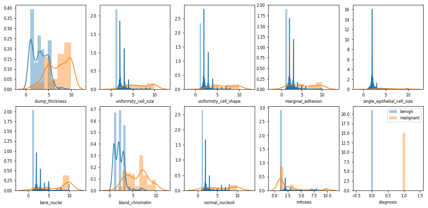

```python
ncols=5
nrows=2
fig, ax = plt.subplots(nrows,ncols,figsize=(15,7))
i=0
for row in range(nrows):
    for col in range(ncols):
        sns.distplot(df[cols[i]][df[cols[-1]]==0],ax=ax[row][col], label='benign')
        sns.distplot(df[cols[i]][df[cols[-1]]==1],ax=ax[row][col], label='malignant')
        i+=1
ax[row][col].legend()
```

```python
feature_names = list(cancer_df.columns[0:9])
# split dataframe into two based on diagnosis
dfM = cancer_df[cancer_df['diagnosis'] == 1]
dfB = cancer_df[cancer_df['diagnosis'] == 0]
```

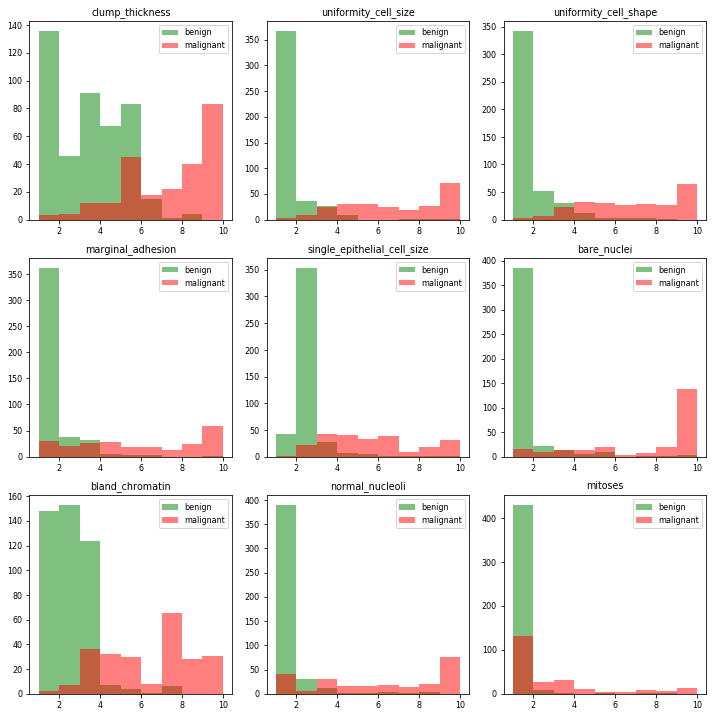

```python
fig, axes = plt.subplots(nrows=3, ncols=3, figsize=(10,10))
axes = axes.ravel()
for idx, ax in enumerate(axes):
    bins = list(range(1,11))
    feature = feature_names[idx]
    ax.hist(dfB[feature].values, bins, alpha=0.5, label='benign', color='g')
    ax.hist(dfM[feature].values, bins, alpha=0.5, label='malignant', color='r')
    ax.legend(loc='upper right')
    ax.set_title(feature)

plt.tight_layout()
plt.show()
```

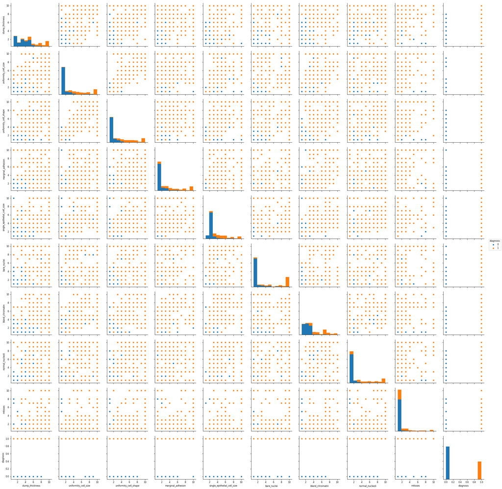

```python
sns.pairplot(cancer_df, hue='diagnosis')
```

```python
from sklearn.decomposition import PCA

X = df.drop(['diagnosis'], axis=1)
Y = df['diagnosis']

pca = PCA(5)
pca.fit(X)

X_new = pca.transform(X)
X_new.shape
```

```
(682, 5)
```

```python
df_new = pd.DataFrame(np.column_stack([X_new, Y]), columns=['PCA '+str(x) for x in range(1,6)]+['diagnosis'] )
```

```python
pca.explained_variance_ratio_
```

```
array([ 0.69036063,  0.07199027,  0.06059305,  0.04444494,  0.03902693])
```

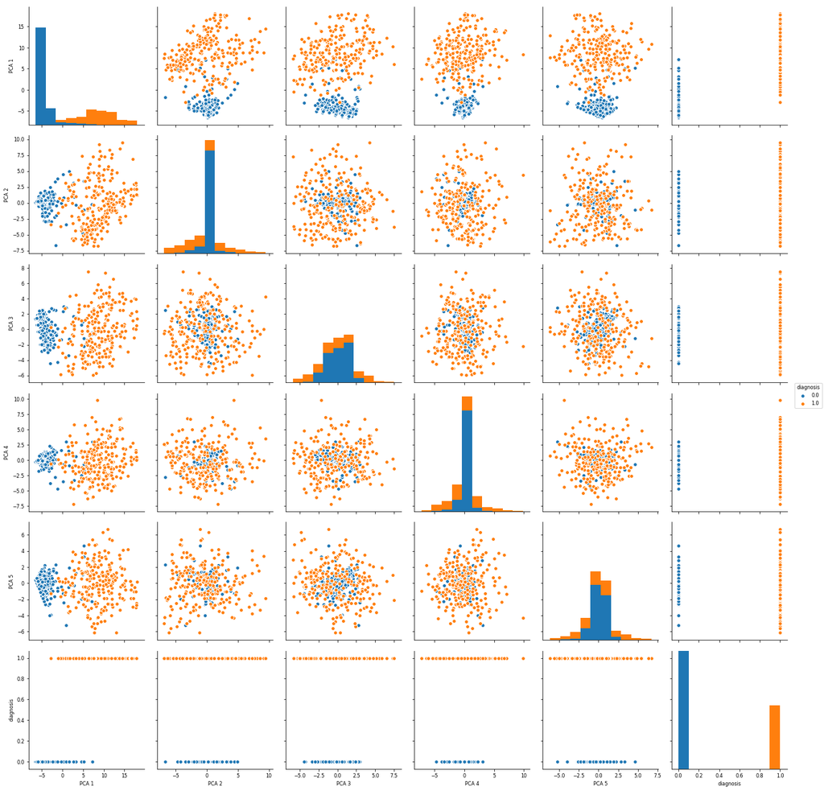

```python
# The 1st PCA component explaines 69% of variance. In the following pair-plots,
# I show that the dataset can almost be linearly separated.
sns.pairplot(df_new, hue="diagnosis", size=3)
```

### Feature Selection 2 - Feature correlation

Now I draw a correlation graph so that we can remove multi colinearity. It means the columns are dependenig on each other so we should avoid it because we don't want to use same column twice.

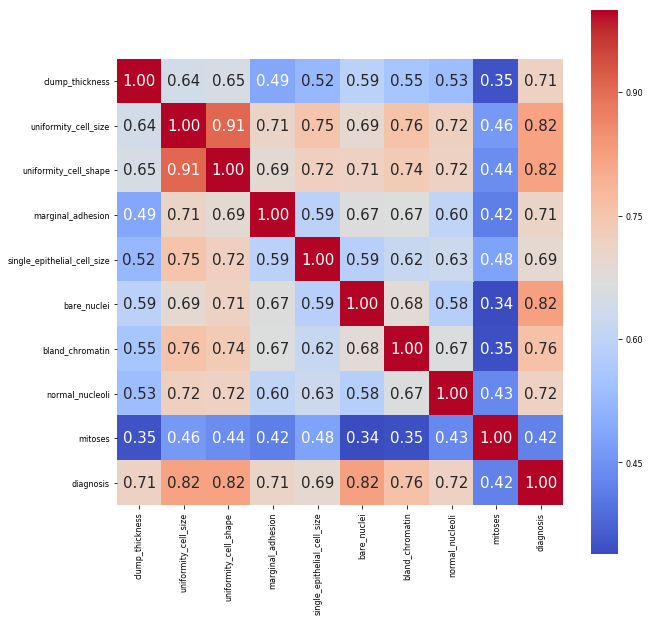

```python
# check the correlation between features
# parameters = feature_names # without class label
parameters = cancer_df.columns # with class label

corr = cancer_df[parameters].corr() # .corr is used for find corelation
plt.figure(figsize=(10,10))
sns.heatmap(corr, cbar = True, square = True, annot=True, fmt= '.2f', annot_kws={'size': 15},
            xticklabels= parameters, yticklabels= parameters, cmap= 'coolwarm')
```

#### Observation:

The uniformity_cell_size and uniformity_cell_shape are highly correlated. We can choose any of it for our further analysis / model building. We will use uniformity_cell_size from here.

```python
## Define linear correlation matrix
# http://www.statisticssolutions.com/correlation-pearson-kendall-spearman/
def plot_correlation_matrix(data, target_name=None,
                            labels=None, **kwds):
    """
    To calculate pairwise correlation between features.
    Extra arguments are passed on to DataFrame.corr()
    """

    if (data[target_name[0]] == 4).all(axis=0):
        label = labels[0]
        data = data.drop(labels=target_name, axis=1, inplace=False)
    elif (data[target_name[0]] == 2).all(axis=0):
        label = lables[1]
        data = data.drop(labels=target_name, axis=1, inplace=False)
    else:
        label = "all"

    # Add colorbar, make sure to specify tick locations to match desired ticklabels
    labels = data.corr(**kwds).columns.values

    fig, ax1 = plt.subplots(ncols=1, figsize=(8, 7))
    ax1.set_title("Correlations: " + label)

    args = {"annot": True, "ax": ax1, "vmin": 0, "vmax": 1, "annot_kws": {"size": 8},
            "cmap": plt.get_cmap("Blues", 20)}

    # Correlations are calculated with .corr() method
    sns.heatmap(data.corr(method="spearman"), **args)

    for ax in (ax1,):
        # shift location of ticks to center of the bins
        ax.set_xticks(np.arange(len(labels))+0.5, minor=False)
        ax.set_yticks(np.arange(len(labels))+0.5, minor=False)

        ax.set_xticklabels(labels, minor=False, ha="right", rotation=70)
        ax.set_yticklabels(labels, minor=False)

    plt.yticks(rotation=0)
    plt.xticks(rotation=90)

    plt.tight_layout()

    return display(plt.show())
```

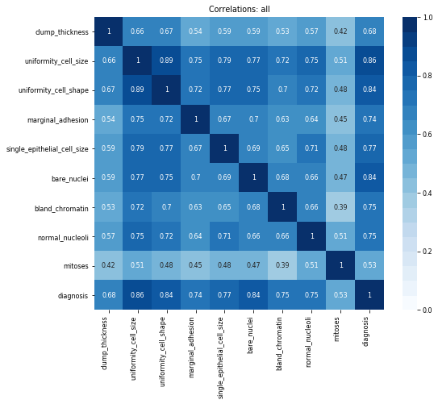

```
None
```

```python
plot_correlation_matrix(cancer_df, target_name=['diagnosis'],
                        labels=['Malignant', "Benign"])
```

### Based on the above feature selection analysis, we exclude both mitosis and uniformity_cell_shape features in our model

```python
# drop both mitosis and uniformity_cell_shape column
cancer_df.drop("mitoses", axis=1, inplace=True)
cancer_df.drop("uniformity_cell_shape", axis=1, inplace=True)
```

```python
cancer_df.head()
```

|  | clump_thickness | uniformity_cell_size | marginal_adhesion | single_epithelial_cell_size | bare_nuclei | bland_chromatin | normal_nucleoli | diagnosis |
| --- | --- | --- | --- | --- | --- | --- | --- | --- |
| 1000025 | 5 | 1 | 1 | 2 | 1 | 3 | 1 | 0 |
| 1002945 | 5 | 4 | 5 | 7 | 10 | 3 | 2 | 0 |
| 1015425 | 3 | 1 | 1 | 2 | 2 | 3 | 1 | 0 |
| 1016277 | 6 | 8 | 1 | 3 | 4 | 3 | 7 | 0 |
| 1017023 | 4 | 1 | 3 | 2 | 1 | 3 | 1 | 0 |

## 3. Modeling

### 3.0 Train, Test Set Spliting

```python
from sklearn.model_selection import train_test_split

train_df, test_df = train_test_split(cancer_df, test_size=0.2, random_state=10)
                                     #,stratify=cancer_df['diagnosis'])# stratify the outcome

X_train = train_df[train_df.columns[0:7]]
X_test = test_df[test_df.columns[0:7]]
y_train = train_df['diagnosis']
y_test = test_df['diagnosis']
```

- Scaling

Not all classification methods need scaled dataset. This would be helpful if we want to explore more to use alogorithms like SVM or ANN.

```python
from sklearn.preprocessing import StandardScaler

# fit a standardScaler to normalize all input to zero mean and unit variance
#scaler = StandardScaler().fit(X_train)
#X_train = pd.DataFrame(scaler.transform(X_train), columns = X_train.columns)
#X_test = pd.DataFrame(scaler.transform(X_test), columns = X_test.columns)
```

### 3.1 Random Forest Model

### Classification

```python
from sklearn.ensemble import RandomForestClassifier

clf_rf = RandomForestClassifier(n_estimators=100)

clf_rf.fit(X_train, y_train)
y_predicted_rf = clf_rf.predict(X_test)
```

### Model Evaluation

Let's start by looking at some metrics to see if our classifier performed well at all.

```python
from sklearn.metrics import accuracy_score, f1_score, precision_score, recall_score, classification_report

def get_metrics(y_test, y_predicted):
    # true positives / (true positives+false positives)
    precision = precision_score(y_test, y_predicted, pos_label=None,
                                    average='weighted')
    # true positives / (true positives + false negatives)
    recall = recall_score(y_test, y_predicted, pos_label=None,
                              average='weighted')

    # harmonic mean of precision and recall
    f1 = f1_score(y_test, y_predicted, pos_label=None, average='weighted')

    # true positives + true negatives/ total
    accuracy = accuracy_score(y_test, y_predicted)
    return accuracy, precision, recall, f1
```

```python
accuracy, precision, recall, f1 = get_metrics(y_test, y_predicted_rf)
print("accuracy = %.3f, precision = %.3f, recall = %.3f, f1 = %.3f" % (accuracy, precision, recall, f1))
```

```
accuracy = 0.956, precision = 0.957, recall = 0.956, f1 = 0.956
```

#### Precision Recall Threshold

```python
from sklearn.metrics import precision_recall_curve

y_prob = clf_rf.predict_proba(X_test)[:,1]
p, r, thresholds = precision_recall_curve(y_test, y_prob)
```

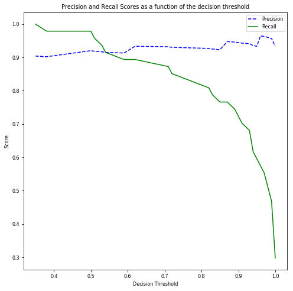

```python
def plot_precision_recall_vs_threshold(precisions, recalls, thresholds):
    """
    Modified from:
    Hands-On Machine learning with Scikit-Learn
    and TensorFlow; p.89
    """
    plt.figure(figsize=(8, 8))
    plt.title("Precision and Recall Scores as a function of the decision threshold")
    plt.plot(thresholds, precisions[:-1], "b--", label="Precision")
    plt.plot(thresholds, recalls[:-1], "g-", label="Recall")
    plt.ylabel("Score")
    plt.xlabel("Decision Threshold")
    plt.legend(loc='best')

plot_precision_recall_vs_threshold(p, r, thresholds)
```

#### ROC curve

```python
from sklearn.metrics import roc_curve, auc

fpr, tpr, thresholds = roc_curve(y_test, y_prob, pos_label=1)
auc = auc(fpr,tpr)
```

[output not shown]

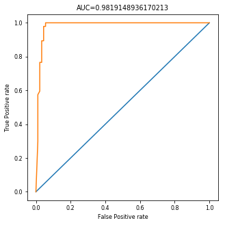

```python
plt.figure(figsize=(5,5))
#fpr, tpr, thresholds = roc_curve(y_test, y_prob, pos_label=1)
plt.plot(np.arange(10)/9., np.arange(10)/9.)
plt.plot(fpr,tpr)
plt.xlabel('False Positive rate')
plt.ylabel('True Positive rate')
plt.title('AUC={0}'.format(auc))
```

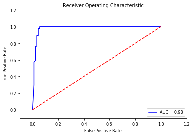

```python
# 2
plt.title('Receiver Operating Characteristic')
plt.plot(fpr, tpr, 'b', label='AUC = %0.2f'% auc)
plt.legend(loc='lower right')
plt.plot([0,1],[0,1],'r--')
plt.xlim([-0.1,1.2])
plt.ylim([-0.1,1.2])
plt.ylabel('True Positive Rate')
plt.xlabel('False Positive Rate')
plt.show()
```

### Inspection

In order to make an actionnable decision, we need to actually inspect the kind of mistakes our classifier is making. Let's start by looking at the confusion matrix.

```python
from sklearn.metrics import confusion_matrix

def plot_confusion_martix(y_test, y_predicted):
    cm = confusion_matrix(y_test, y_predicted)
    cm = cm.astype('float') / cm.sum(axis=1)[:, np.newaxis] # normalize
    cm = np.round(cm, 2)

    tag_list = ['Benign', 'Malignant']
    df_cm = pd.DataFrame(cm, index = tag_list, columns = tag_list)

    plt.figure(figsize = (5,4))
    sns.set(font_scale=1.5) #for label size
    sns.heatmap(df_cm, annot=True, cmap="YlGnBu", fmt='g')

    plt.title('Confusion Matrix\n')
    plt.xlabel('\nPredicted Label')
    plt.ylabel('True Label\n')
```

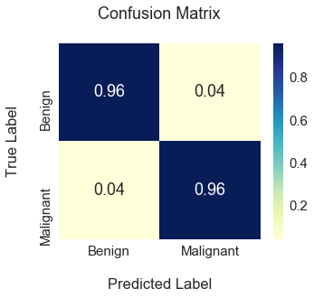

```python
plot_confusion_martix(y_test, y_predicted_rf)
```

```python
def plot_confusion_matrix(cm, classes,
                          normalize=False,
                          title='Confusion matrix',
                          cmap=plt.cm.Blues):
    """
    This function prints and plots the confusion matrix.
    Normalization can be applied by setting `normalize=True`.
    """
    if normalize:
        cm = cm.astype('float') / cm.sum(axis=1)[:, np.newaxis]
        print("Normalized confusion matrix")
    else:
        print('Confusion matrix, without normalization')

    plt.imshow(cm, interpolation='nearest', cmap=cmap)
    plt.title(title)
    plt.colorbar()
    tick_marks = np.arange(len(classes))
    plt.xticks(tick_marks, classes, rotation=45)
    plt.yticks(tick_marks, classes)

    fmt = '.2f' if normalize else 'd'
    thresh = cm.max() / 2.
    for i, j in itertools.product(range(cm.shape[0]), range(cm.shape[1])):
        plt.text(j, i, format(cm[i, j], fmt),
                 horizontalalignment="center",
                 color="white" if cm[i, j] > thresh else "black")

    plt.tight_layout()
    plt.ylabel('True label')
    plt.xlabel('Predicted label')
```

```
Normalized confusion matrix
```

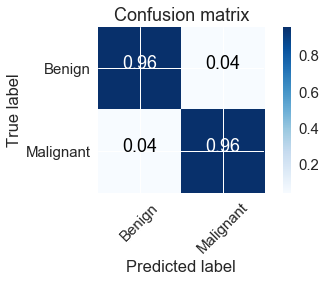

```python
cm = confusion_matrix(y_test, y_predicted_rf)

plot_confusion_matrix(cm,classes=['Benign','Malignant'],normalize=True)
plt.show()
```

### Feature Importance

Now let's look at the features our classifier is using to make decisions.

```
Feature ranking:
1. feature uniformity_cell_size (0.293841)
2. feature single_epithelial_cell_size (0.226832)
3. feature bare_nuclei (0.131900)
4. feature marginal_adhesion (0.125126)
5. feature bland_chromatin (0.098222)
6. feature clump_thickness (0.073889)
7. feature uniformity_cell_shape (0.050190)
```

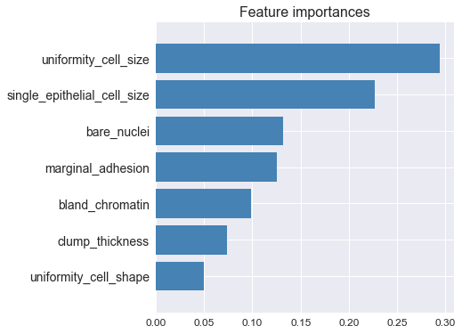

```python
clf = clf_rf

importances = clf.feature_importances_
std = np.std([clf.feature_importances_ for tree in clf.estimators_],
             axis=0)
indices = np.argsort(importances)[::-1]

# Print the feature ranking
print("Feature ranking:")

for f in range(X_train.shape[1]):
    print("%d. feature %s (%f)" % (f + 1, cols[indices[f]], importances[indices[f]]))

# Plot the feature importances of the forest
plt.figure(figsize=(6,6))
plt.title("Feature importances",size=16)
plt.barh(range(X_train.shape[1]), importances[indices],
       color="steelblue", yerr=std[indices], align="center")
plt.yticks(range(X_train.shape[1]), [cols[index] for index in indices], size=14), #{'rotate':45})
plt.ylim([X_train.shape[1],-1])
plt.xticks(size=12)
plt.show()
```

```
Feature ranking:
1. uniformity_cell_size (0.293841)
2. bare_nuclei (0.226832)
3. bland_chromatin (0.131900)
4. single_epithelial_cell_size (0.125126)
5. normal_nucleoli (0.098222)
6. clump_thickness (0.073889)
7. marginal_adhesion (0.050190)
```

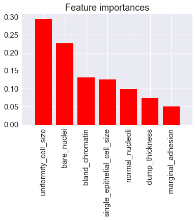

```python
importances = clf_rf.feature_importances_
indices = np.argsort(importances)[::-1]

# Print the feature ranking
print("Feature ranking:")

x_tick = []
for f in range(X_train.shape[1]):
    print("%d. %s (%f)" % (f + 1, X_train.columns[indices[f]], importances[indices[f]]))
    x_tick.append(X_train.columns[indices[f]])

# Plot the feature importances of the forest
plt.figure()
plt.title("Feature importances")
plt.bar(range(X_train.shape[1]), importances[indices],
       color="r", align="center")

plt.xticks(range(X_train.shape[1]), x_tick, rotation='vertical')
plt.xlim([-1, X_train.shape[1]])
plt.show()
```

So to predict if a biopsied breast cell is benign or malignant, the top 3 most importance features are Uniformity of Cell Size, Bare Nuclei and Bland Chromatin. It is interesting that Random Forest didn't pick up Dump Thickness as an important feature, which, however shows to be a strong indicator to classify benign and malignant cells in the Nucleus features vs Diagnosis figure.

### Grid Search

```python
from sklearn.grid_search import GridSearchCV
from sklearn.metrics import make_scorer
from sklearn.metrics import roc_auc_score

score = make_scorer(roc_auc_score, greater_is_better=True)

rfc = RandomForestClassifier(n_jobs=-1, max_features='sqrt', oob_score = True)


# Use a grid over parameters of interest
param_grid = {
           "n_estimators" : [50, 100, 200],
           "max_depth" : [5, 10, 20],
           "min_samples_leaf" : [1, 3, 5]}

CV_rfr = GridSearchCV(estimator=rfc, param_grid=param_grid, scoring=score, cv= 5)
CV_rfr.fit(X_train, y_train)
print (CV_rfr.best_params_)
```

```
{'max_depth': 20, 'min_samples_leaf': 5, 'n_estimators': 200}
```

```python
CV_rfr.cv_results_
```

[output not shown]

```python
from sklearn import cross_validation
print(cross_validation.cross_val_score(CV_rfr, X_train,y_train).mean())
```

```
0.965250992926
```

```python
rf_best = CV_rfr.best_estimator_
```

```python
y_train_predict = rf_best.predict(X_train)
y_test_predict = rf_best.predict(X_test)
```

```python
accuracy, precision, recall, f1 = get_metrics(y_test, y_test_predict)
print("accuracy = %.3f, precision = %.3f, recall = %.3f, f1 = %.3f" % (accuracy, precision, recall, f1))
```

```
accuracy = 0.964, precision = 0.965, recall = 0.964, f1 = 0.964
```

### 3.2 Logistic Regression Model

### Build Model

```python
from sklearn.linear_model import LogisticRegression


clf_lr = LogisticRegression(C=30.0, class_weight='balanced', solver='newton-cg',
                         multi_class='multinomial', n_jobs=-1, random_state=40)

clf_lr.fit(X_train, y_train)

y_predicted_lr = clf_lr.predict(X_test)
```

### Model Evaluation

```python
accuracy, precision, recall, f1 = get_metrics(y_test, y_predicted_lr)
print("accuracy = %.3f, precision = %.3f, recall = %.3f, f1 = %.3f" % (accuracy, precision, recall, f1))
```

```
accuracy = 0.949, precision = 0.949, recall = 0.949, f1 = 0.949
```

### Inspection - Confusion Matrix

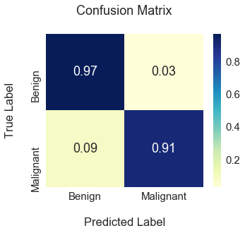

```python
plot_confusion_martix(y_test, y_predicted_lr)
```

#### Observation:

Logistic regression model generated almost the same result as the random forest model.

### Feature Importance

```
Feature ranking:
1. clump_thickness (0.401409)
2. bare_nuclei (0.248726)
3. bland_chromatin (0.222026)
4. marginal_adhesion (0.218221)
5. normal_nucleoli (0.201406)
6. uniformity_cell_size (0.128531)
7. single_epithelial_cell_size (0.007059)
```

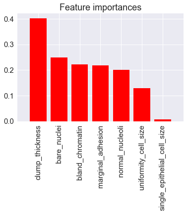

```python
importances = clf_lr.coef_[0]
indices = np.argsort(importances)[::-1]

# Print the feature ranking
print("Feature ranking:")

x_tick = []
for f in range(X_train.shape[1]):
    print("%d. %s (%f)" % (f + 1, X_train.columns[indices[f]], importances[indices[f]]))
    x_tick.append(X_train.columns[indices[f]])

# Plot the feature importances of the forest
plt.figure()
plt.title("Feature importances")
plt.bar(range(X_train.shape[1]), importances[indices],
       color="r", align="center")

plt.xticks(range(X_train.shape[1]), x_tick, rotation='vertical')
plt.xlim([-1, X_train.shape[1]])
plt.show()
```

### ROC curve on various algorithms

```python
from sklearn.metrics import roc_curve, auc
import time

def plot_roc_curves(classifiers, X, y):
    """Produce ROC curves for models given feature set X and labels y
    """
    X_train, X_test, y_train, y_test = train_test_split(X, y, test_size=.2, random_state=41)
    plt.figure(figsize=(8,8))
    for classifier in classifiers:
        print('Working on '+classifier+' classifier...')
        startclass=time.time()
        clf_train=classifiers[classifier].fit(X_train, y_train)
        #pickle.dump(clf_train,open(os.getcwd()+'/classifiers/'+classifier+'.classifier','wb'))
        y_score = clf_train.predict_proba(X_test)[:, 1]

        fpr, tpr, _ = roc_curve(y_test, y_score)
        roc_auc = auc(fpr, tpr)

        plt.plot(fpr, tpr, lw=2, label='%s (area = %0.2f)' % (classifier, roc_auc))
        print(classifier+' classifier took '+str(time.time()-startclass)+' seconds.')
    #plt.axis('equal')
    plt.tick_params(labelsize=20)
    plt.plot([0, 1], [0, 1], color='navy', lw=2, linestyle='--')
    plt.xlim([0.0, 1.0])
    plt.ylim([0.0, 1.05])
    plt.xlabel('False Positive Rate',fontsize = 20)
    plt.ylabel('True Positive Rate',fontsize = 20)
    plt.title('Receiver operating characteristic')
    plt.legend(loc="lower right",fontsize = 20)
    plt.axis('equal')
    #plt.savefig(os.getcwd()+'/graphs/ROC_curves', format='png')
```

```
Working on SVC classifier...
SVC classifier took 0.06695818901062012 seconds.
Working on KNeighbors classifier...
KNeighbors classifier took 0.009373903274536133 seconds.
Working on RandomForest classifier...
RandomForest classifier took 0.12311625480651855 seconds.
```

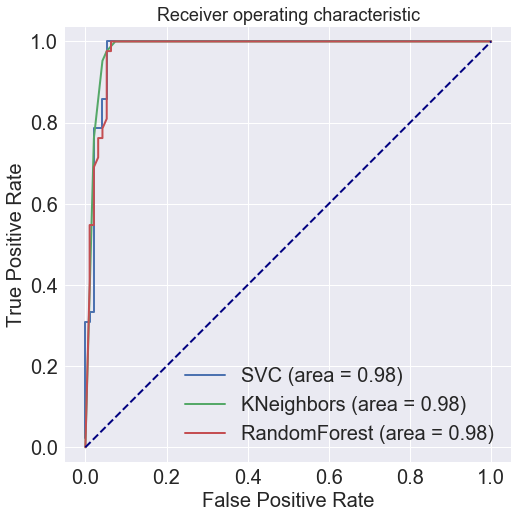

```python
from sklearn.neighbors import KNeighborsClassifier
from sklearn.ensemble import RandomForestClassifier
from sklearn.svm import SVC

X=cancer_df.loc[:, cancer_df.columns != 'diagnosis']
y=cancer_df['diagnosis'].values

clfs=dict()
clfs['SVC']=SVC(probability=True)
clfs['KNeighbors']=KNeighborsClassifier(n_neighbors=7)
clfs['RandomForest']=RandomForestClassifier(n_estimators=100,max_depth=2,min_samples_leaf=100, random_state=0)
plot_roc_curves(clfs, X, y)
```

## 4. Conclusion

In this data challenge, I took a deep look into the data and built two models to predict whether a biopsied breast cell is benign (not harmful) or malignant (cancerous), given a set of attributes about the cell.

Further work will be using cross-validation to fine tune the hyperparameters for our model. And other models like SVM and ANN can also be tried to see if we can improve the prediction. The final goal is to **minimize the false negatives**.****

## 5. More Analysis

### 5.x Class imbalance (not important)

When we train a classifier we'll have to resample accordingly.

There are two common choices when dealing with imbalanced data. One is upsampling; duplicating or artificially generating more points from your minority class. For us that means generating more malignant tumors. The other is downlsampling; deleting or ignoring points from your majority class.

### 5.x Duplicate rows

- Brain OGorman

It is unclear why we might have some instances of just the ID being duplicated and other instances where the entire rows are. There is an additional data file from the original source (https://archive.ics.uci.edu/ml/machine-learning-databases/breast-cancer-wisconsin/breast-cancer-wisconsin.names) that provides some additional information. After spot-checking a handful of these duplicates, it appears that cases where the entire rows are duplicated were samples that were taken on the same date. Cases where only the sample_id is duplicated are from different dates. Based on this, I am going to drop the entries where the entire rows are duplicated, but not those where only the sample_id is.

```python
print('There are {} duplicate rows.'.format(len(data[data.duplicated()])))
```

[output not shown]

```python
data[data.duplicated(keep=False)].sort_values('sample_id').head(10)
```

[output not shown]

```python
data[data.duplicated('sample_id', keep=False)].sort_values('sample_id').head(10)
```

[output not shown]

### 5.x Analyze Recall

A high recall is good because we want to make sure we detect as many possible malignant samples as possible, even if that means having some false positives

### 5.x More on Correlation

- the paramter mitoses are minimally correlated to the class of the tumour.
- can plot with class_label, and see mitoses is even less correlated with the class_label

### 5.X Chris

- remove most important feature, then see what's going on
- try different models, plot ROC curve

Some things to think about going forward:

I noticed that the performance was fairly robust against reevaluations of this notebook but the features and their importance varied a fair bit. To combat this I could bootstrap and bag the results to average the model over different training data. I could try using PCA or another tool for dimensionality reduction to infer "better" observables that could be used going forward in biopsy diagnostics. However, this could be a dead end as it may not be interpretable.